# Summary report for Clanfield

UKMON

2017-07-18

# Summary of activity in 2017

Clanfield operates 5 cameras.

In 2017 Clanfield has recorded 1393 individual meteor observations. These observations comprise 378 sporadic meteors and 1015 stream meteors. A breakdown by month is shown below.

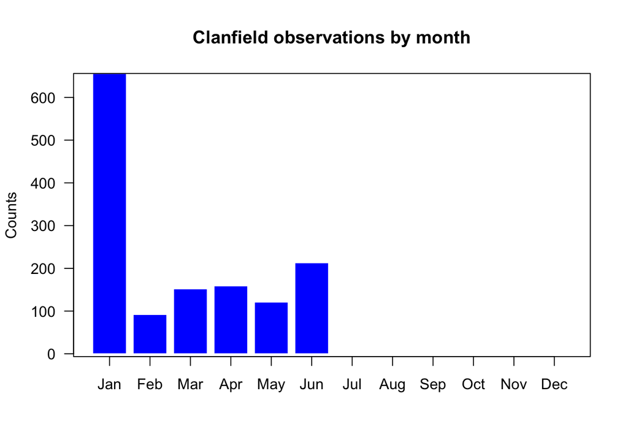

The following shows observation counts by stream for the 20 most frequent showers based on preliminary UFO ANALYSIS classifications:

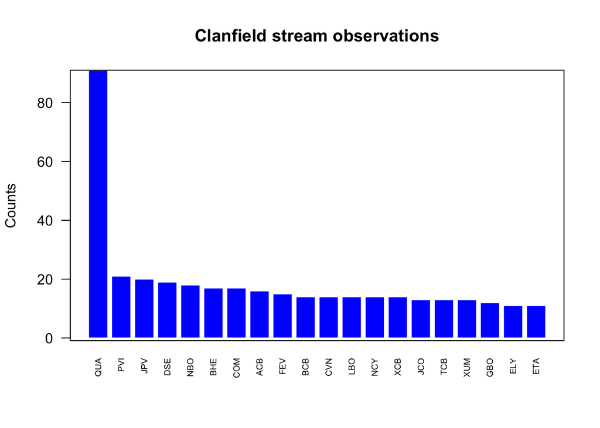

The following table shows which stations are generating matched observations with this station and the number of matches:

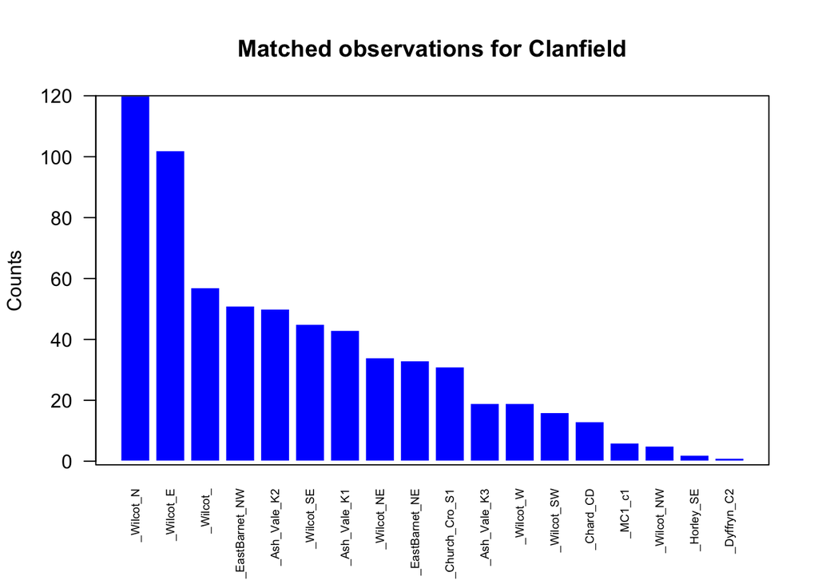

## Fireball activity

(Based on IAU definition of apparrent magnitude of -4.0 of greater)

| Datetime | Magnitude | Duration | Stream |
| --- | --- | --- | --- |
| 2017-03-25 00:03:36 | -4.6 | 1.26 | FHE |

# Observations recorded by Clanfield, 2012 to 2017

UKMON data for Clanfield covers the period from 2012 to 2017 and totals 13923 individual meteor observations. These observations comprise 4006 sporadic meteors and 9917 stream meteors.

This section provides a summary of all observations by Clanfield from 2012 to 2017. A breakdown of the number of observations by year is given in the histogram below.

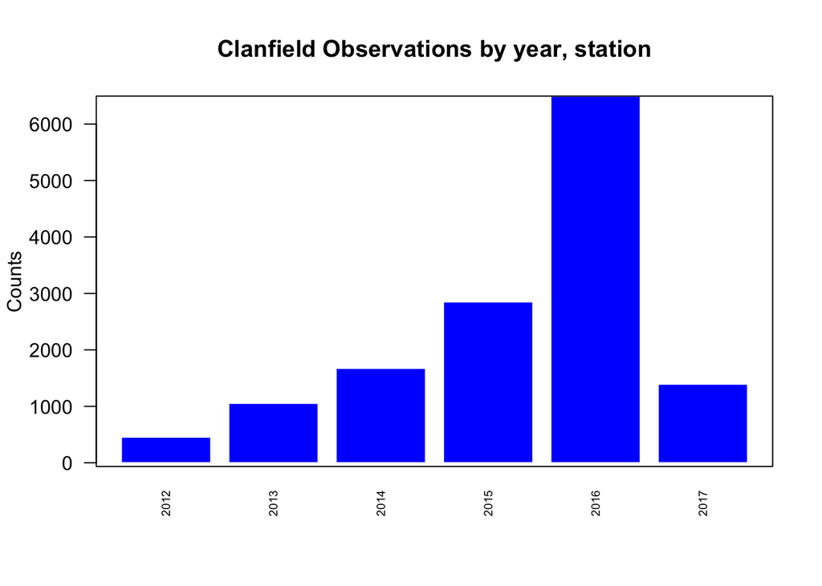

The following graph shows observation counts by stream (preliminary UFO ANALYSIS classification). A detailed breakdown by shower is given in the table at the end of this report.

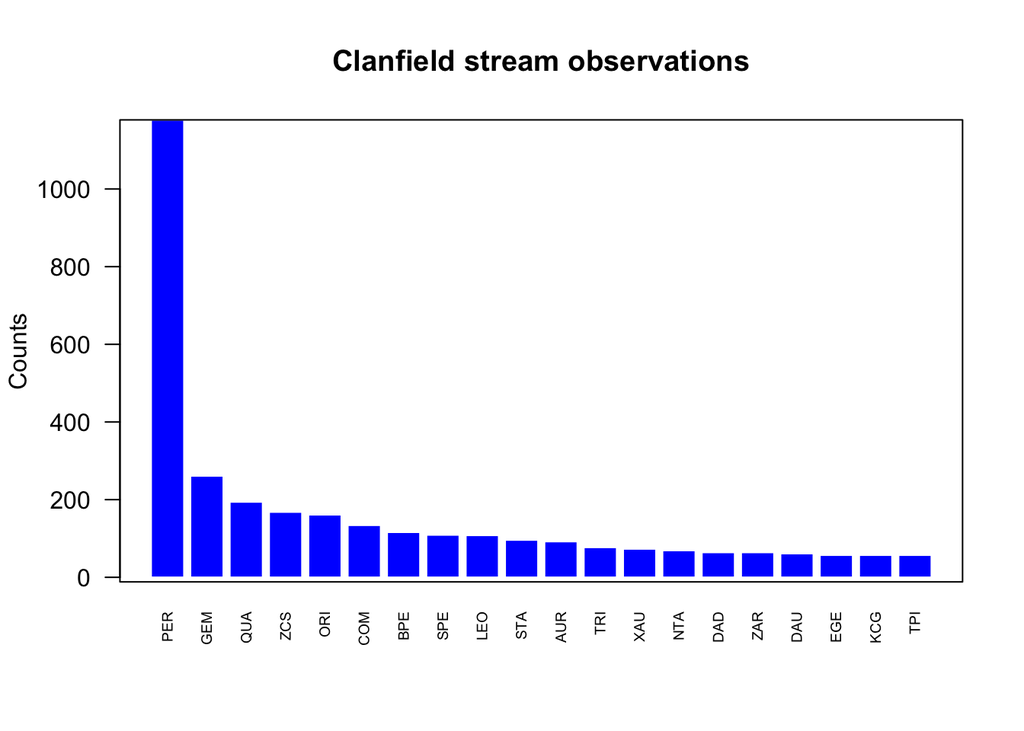

## Fireball activity

Fireballs recorded (Based on IAU definition of apparrent magnitude of -4.0 of greater)

| Datetime | Magnitude | Duration | Stream |
| --- | --- | --- | --- |
| 2015-07-19 22:40:41 | -9.2 | 1.26 | SPO |
| 2014-08-13 02:53:24 | -7.6 | 0.66 | PER |
| 2014-07-17 01:18:54 | -7.0 | 0.72 | CAN |
| 2014-04-07 23:17:03 | -6.3 | 1.92 | SPO |
| 2015-11-28 01:51:30 | -6.2 | 2.26 | AND |
| 2015-07-23 02:22:34 | -6.1 | 0.16 | ZED |
| 2014-05-25 00:32:33 | -6.0 | 0.50 | ELY |
| 2014-09-01 23:01:59 | -6.0 | 1.10 | AUD |
| 2014-08-13 00:47:23 | -5.9 | 0.78 | KCG |
| 2015-09-25 04:02:14 | -5.9 | 0.36 | PSA |
| 2016-08-12 00:10:21 | -5.9 | 0.96 | PER |
| 2014-08-13 03:32:21 | -5.8 | 0.54 | PER |
| 2015-01-04 02:26:57 | -5.7 | 0.68 | SPO |
| 2015-07-22 01:47:17 | -5.7 | 0.28 | ATR |
| 2015-10-17 21:05:13 | -5.7 | 2.16 | STA |
| 2014-08-11 22:35:53 | -5.6 | 0.84 | KCG |
| 2014-09-07 03:42:24 | -5.6 | 0.46 | SPE |
| 2016-02-03 22:46:00 | -5.6 | 3.16 | SPO |
| 2014-12-15 00:29:32 | -5.5 | 0.34 | EPV |
| 2014-08-26 21:42:13 | -5.4 | 0.46 | ICE |
| 2015-09-12 21:09:45 | -5.3 | 0.08 | SPO |
| 2014-08-19 23:52:18 | -5.2 | 0.08 | BPE |
| 2015-12-05 03:39:10 | -5.2 | 0.36 | HYD |
| 2016-02-28 01:56:11 | -5.2 | 0.88 | NDL |
| 2015-09-13 01:34:11 | -5.0 | 0.76 | NPI |
| 2015-11-23 02:40:17 | -5.0 | 0.52 | RBO |
| 2016-04-20 00:51:09 | -5.0 | 1.36 | SPO |
| 2014-06-30 02:04:25 | -4.9 | 0.32 | SPO |
| 2014-08-07 00:49:01 | -4.9 | 0.62 | PER |
| 2014-08-13 00:25:47 | -4.8 | 0.84 | PER |

[output cut: 51 more lines]

The following table shows which stations are generating matched observations with this station and the number of matches:

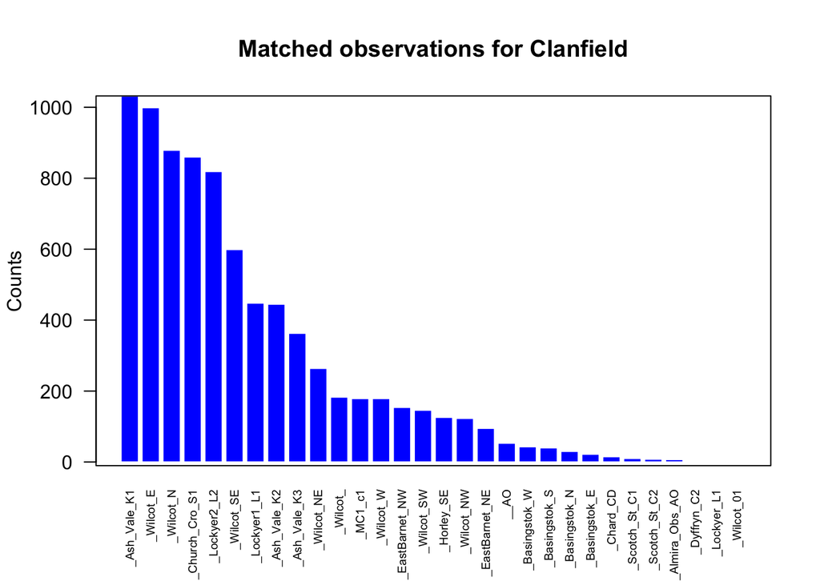

# Detailed counts (including sporadics)

| Shower | Counts |
| --- | --- |
| SPO | 4006 |
| PER | 1178 |
| GEM | 261 |
| QUA | 194 |
| ZCS | 168 |
| ORI | 161 |
| COM | 134 |
| BPE | 116 |
| SPE | 109 |
| LEO | 108 |
| STA | 96 |
| AUR | 92 |
| TRI | 77 |
| XAU | 73 |
| NTA | 69 |
| DAD | 64 |
| ZAR | 64 |
| DAU | 61 |
| EGE | 57 |
| KCG | 57 |
| TPI | 57 |
| HYD | 56 |
| SIC | 53 |
| BAU | 52 |
| URS | 52 |
| NOO | 51 |
| PSA | 51 |
| ATR | 50 |
| LYR | 50 |
| DSE | 49 |

[output cut: 379 more lines]